# Pilot ECDRE 16S comparison

Jason Stajich

November 8, 2021

## Comparing the DNA extraction protocol and 16S profile

```r
library(ape)
library(vegan)
library(dplyr)
library(scales)
library(grid)
library(reshape2)
library(phyloseq)
library(magrittr)
library(ggplot2)
library(ggpubr)
library(plyr)
library(data.table)
library(tidyr)
library(tidyverse)
```

###STEP2: Import Mapping file (metadate file) 1.Check mapping file before import to R, R doesn’t seem to like sample name to start with number or contain “-” in sample name. If you get error in this step, you should check file name first.

2.First column of first row should not start with #, R will not read the first row that starts with #

```r
metatable = file.path(knitr::opts_chunk$get("root.dir"),"Pilot_16S.mapping_file.txt")
meta = read.table(metatable,header=TRUE,row.names=1,sep=",",stringsAsFactors=FALSE)
rownames(meta) <- gsub('-','.',rownames(meta))
```

If need to keep or remove some samples

```r
meta <- meta[which(meta$DemuxReads > min_read_count),]
```

###STEP3: Check if your metadata file has been import successfully and correctly

The output will show a table of your metadata file (mapping file).

*If you do not have header, you might have started your first row with #

```r
head(meta)
```

```
##                          RevBarcodeSequence        ReversePrimer
## Leaf.Ctrl2              GTGYCAGCMGCCGCGGTAA GGACTACNVGGGTWTCTAAT
## Leaf.L3.9.Mericon100.1  GTGYCAGCMGCCGCGGTAA GGACTACNVGGGTWTCTAAT
## Leaf.L3.9.Mericon100.2  GTGYCAGCMGCCGCGGTAA GGACTACNVGGGTWTCTAAT
## Leaf.L3.9.PlantPro100.1 GTGYCAGCMGCCGCGGTAA GGACTACNVGGGTWTCTAAT
## Leaf.L7.PlantPro100.1   GTGYCAGCMGCCGCGGTAA GGACTACNVGGGTWTCTAAT
## Leaf.L7.PlantPro100.2   GTGYCAGCMGCCGCGGTAA GGACTACNVGGGTWTCTAAT
##                                        phinchID DemuxReads Treatment Tissue
## Leaf.Ctrl2                           Leaf-Ctrl2      32828     LeafC   Leaf
## Leaf.L3.9.Mericon100.1   Leaf-L3.9-Mericon100-1    3060415    LeafL3   Leaf
## Leaf.L3.9.Mericon100.2   Leaf-L3.9-Mericon100-2    2520701    LeafL3   Leaf
## Leaf.L3.9.PlantPro100.1 Leaf-L3.9-PlantPro100-1    3143719    LeafL3   Leaf
## Leaf.L7.PlantPro100.1     Leaf-L7-PlantPro100-1    3261774    LeafL7   Leaf
## Leaf.L7.PlantPro100.2     Leaf-L7-PlantPro100.2    3537020    LeafL7   Leaf
##                          Extraction    ExtractByTmt
## Leaf.Ctrl2                  Control     LeafControl
## Leaf.L3.9.Mericon100.1   Mericon100  LeafMericon100
## Leaf.L3.9.Mericon100.2   Mericon100  LeafMericon100
## Leaf.L3.9.PlantPro100.1 PlantPro100 LeafPlantPro100
## Leaf.L7.PlantPro100.1   PlantPro100 LeafPlantPro100
## Leaf.L7.PlantPro100.2   PlantPro100 LeafPlantPro100
```

###STEP4: Construct sample_data-class using imported metadata

```r
sampleData <- sample_data(meta)
```

###STEP5: Import OTU table

```r
otutable <- file.path(knitr::opts_chunk$get("root.dir"), "Pilot_16S.otu_table.txt")
otus <- read.table(otutable,header=T,sep="\t",row.names=1)
otumat <- as(as.matrix(otus), "matrix")
OTU = otu_table(otumat, taxa_are_rows = TRUE)
```

Check imported OTU table

```r
head(OTU)
```

```
## OTU Table:          [6 taxa and 19 samples]
##                      taxa are rows
##          Leaf.Ctrl2 Leaf.L3.9.Mericon100.1 Leaf.L3.9.Mericon100.2
## OTU1           8965                1590154                1179793
## OTU10             0                      0                     46
## OTU100            0                      0                      0
## OTU1000           0                      0                      0
## OTU10000          0                      0                      0
## OTU10002          0                      0                      0
##          Leaf.L3.9.PlantPro100.1 Leaf.L3.9.PlantPro100.2 Leaf.L7.PlantPro100.1
## OTU1                     2129834                       3               2284099
## OTU10                          0                       0                     0
## OTU100                         0                       0                     0
## OTU1000                        0                       0                     0
## OTU10000                       0                       0                     0
## OTU10002                       0                       0                     0
##          Leaf.L7.PlantPro100.2 Leaf.Magmax100.1 Leaf.Magmax100.2 Root.Ctrl.1
## OTU1                   2439456          1373597          1131261         126
## OTU10                        0               61                0           0
## OTU100                       0                0                0           0
## OTU1000                      0                0                0           0
## OTU10000                     0                0                0           0
## OTU10002                     0                0                0           0
##          Root.Ctrl.2 Root.Magmax100.1 Root.Magmax100.2 Root.R3.9.Mericon100.1
## OTU1           10429          1541404          1564314                1519737
## OTU10              0              564              457                   2138
## OTU100             0              140              113                    572
## OTU1000            0                2                2                     19
## OTU10000           0                0                0                      0
## OTU10002           0                0                2                      0
##          Root.R3.9.Mericon100.2 Root.R3.9.PlantPro100.1 Root.R3.9.PlantPro100.2
## OTU1                    1253585                 1981699                 1681259
## OTU10                      2110                   21344                    3462
## OTU100                      463                     892                     441
## OTU1000                      13                      29                      18
## OTU10000                      0                       0                       0
## OTU10002                      0                       0                       0
##          Root.R7.PlantPro100.1 Root.R7.PlantPro100.2
## OTU1                   1435623               1809159
## OTU10                    14847                 16153
## OTU100                     470                   673
## OTU1000                     15                    17
## OTU10000                     2                     0
## OTU10002                     0                     0
```

###STEP6: Import taxonomy table Taxonmy table generated from AMPtk need to be rearranged using following script.

“perl rdp_taxonmy2mat.pl<Input_taxonmy.txt>Output_taxonomy.txt”

rdp_taxonomy2mat.pl was created by Professor Jason E. Stajich

```r
taxin = file.path(knitr::opts_chunk$get("root.dir"),"Pilot_16S.cluster.taxonomy.fix.txt")
taxmat <- read.table(taxin, header=T,sep="\t",row.names=1)
taxmat <- as(as.matrix(taxmat),"matrix")
TAX = tax_table(taxmat)
```

###STEP7: Import phylogenetic tree Phylogenetic tree can also be include for further phylogenetic analysis.

```r
treefile = file.path(knitr::opts_chunk$get("root.dir"),"Pilot_16S.cluster.tree.phy")
tree = read.tree(treefile)
```

###STEP8: Construct Phyloseq object To construct phyloseq object, otu table, taxonomy table, and sampleData are required. Phylogenetic tree can be included, but it is not necessary for constructing phyloseq object. Construct Phyloseq object called “Physeq”

```r
physeq = phyloseq(OTU,TAX,sampleData,tree)
```

Check phyloseq object This should indicate that your physeq is a “phyloseq-class experiment-level object”"

```r
physeq
```

```
## phyloseq-class experiment-level object
## otu_table()   OTU Table:         [ 10752 taxa and 18 samples ]
## sample_data() Sample Data:       [ 18 samples by 8 sample variables ]
## tax_table()   Taxonomy Table:    [ 10752 taxa by 7 taxonomic ranks ]
## phy_tree()    Phylogenetic Tree: [ 10752 tips and 10750 internal nodes ]
```

###STEP9: Remove singletons Remove any OTUs that present only one time.

```r
physeq.prune = prune_taxa(taxa_sums(physeq) > 1, physeq)
```

```r
physeq.prune
```

```
## phyloseq-class experiment-level object
## otu_table()   OTU Table:         [ 10752 taxa and 18 samples ]
## sample_data() Sample Data:       [ 18 samples by 8 sample variables ]
## tax_table()   Taxonomy Table:    [ 10752 taxa by 7 taxonomic ranks ]
## phy_tree()    Phylogenetic Tree: [ 10752 tips and 10750 internal nodes ]
```

###STEP10: Plot read counts to check dataset Check read counts: any samples that have very low reads should be removed. [Ref](http://evomics.org/wp-content/uploads/2016/01/phyloseq-Lab-01-Answers.html)

```r
readcount = data.table(as(sample_data(physeq.prune), "data.frame"),
                 TotalReads = sample_sums(physeq.prune),
                 keep.rownames = TRUE)
setnames(readcount, "rn", "SampleID")
#For plotting, use command below.
#SeqDepth = ggplot(readcount, aes(TotalReads)) + geom_histogram() + ggtitle("Sequencing Depth")
```

```r
readcount = readcount[order(readcount$TotalReads), c("SampleID", "TotalReads")]
```

```r
head(readcount)
```

```
##                  SampleID TotalReads
## 1:            Root.Ctrl.1       1292
## 2:            Root.Ctrl.2      11007
## 3:             Leaf.Ctrl2      28502
## 4: Root.R3.9.Mericon100.2    1397486
## 5:       Root.Magmax100.2    1660809
## 6:       Leaf.Magmax100.2    1727684
```

```r
set.seed(1)
physeq.prune.rarefy = rarefy_even_depth(physeq.prune, sample.size = 1500, replace = FALSE, trimOTUs = FALSE)
```

```
## You set `rngseed` to FALSE. Make sure you've set & recorded
##  the random seed of your session for reproducibility.
## See `?set.seed`
```

```
## ...
```

```
## 1 samples removedbecause they contained fewer reads than `sample.size`.
```

```
## Up to first five removed samples are:
```

```
## Root.Ctrl.1
```

```
## ...
```

```r
physeq.prune.rarefy
```

```
## phyloseq-class experiment-level object
## otu_table()   OTU Table:         [ 10752 taxa and 17 samples ]
## sample_data() Sample Data:       [ 17 samples by 8 sample variables ]
## tax_table()   Taxonomy Table:    [ 10752 taxa by 7 taxonomic ranks ]
## phy_tree()    Phylogenetic Tree: [ 10752 tips and 10750 internal nodes ]
```

###STEP12.1 Taxonomic composition

```r
BactOrder = as.character(get_taxa_unique(physeq.prune.rarefy, "Order"))
BactOrder = BactOrder[complete.cases(BactOrder)]
BactOrder
```

```
##  [1] "Herpetosiphonales"                  "Sphaerobacterales"
##  [3] "Chloroflexales"                     "Bacillales"
##  [5] "Caldilineales"                      "Oceanospirillales"
##  [7] "Pseudomonadales"                    "Syntrophobacterales"
##  [9] "Anaerolineales"                     "Thermomicrobiales"
## [11] "Thermoanaerobacterales"             "Ardenticatenales"
## [13] "Xanthomonadales"                    "Clostridiales"
## [15] "Thermoflexales"                     "Armatimonadales"
## [17] "Chromatiales"                       "Ktedonobacterales"
## [19] "Thermogemmatisporales"              "Actinomycetales"
## [21] "Methylophilales"                    "Sphingomonadales"
## [23] "Burkholderiales"                    "Desulfuromonadales"
## [25] "Desulfovibrionales"                 "Deinococcales"
## [27] "Acholeplasmatales"                  "Mycoplasmatales"
## [29] "Neisseriales"                       "Campylobacterales"
```

[output cut: 34 more lines]

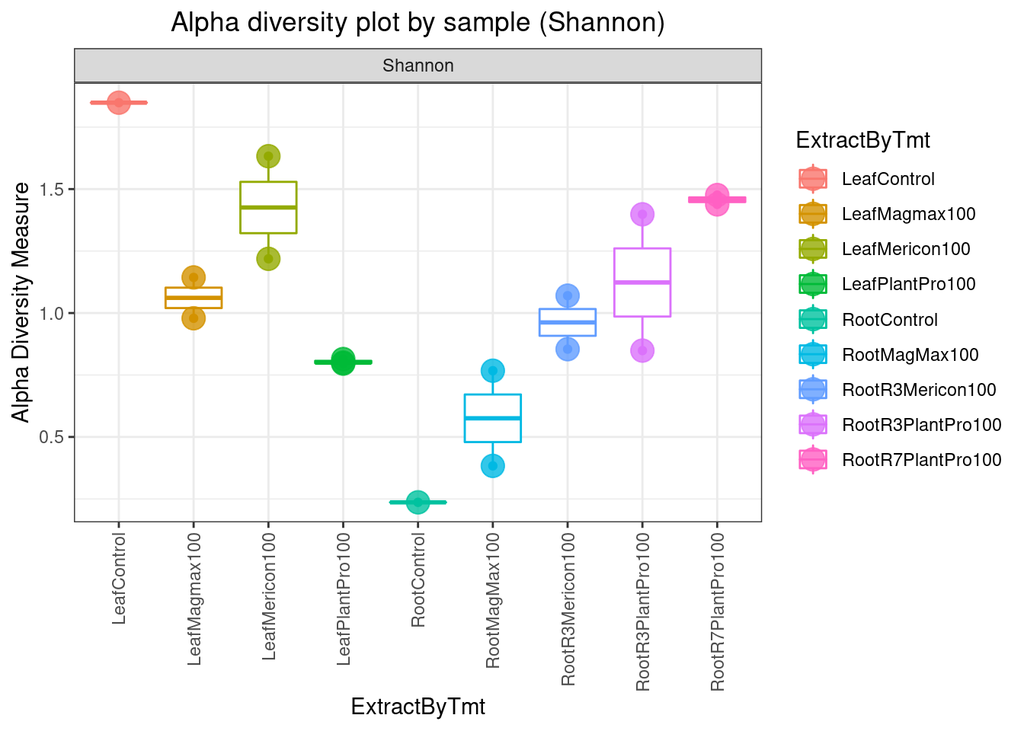

```r
plot_richness(physeq.prune.rarefy, x = "ExtractByTmt", color = "ExtractByTmt", measures = c("Shannon")) +
  geom_boxplot() +
  theme_bw() + ggtitle("Alpha diversity plot by sample (Shannon)") +
  theme(plot.title = element_text(hjust = 0.5),axis.text.x = element_text(angle = 90, vjust = 0.5, hjust=1)) +
  geom_point(size=5, alpha=0.8)
```

###STEP12:Taxonomy Barplot

Taxonomy barplot by sample (Phylum level)

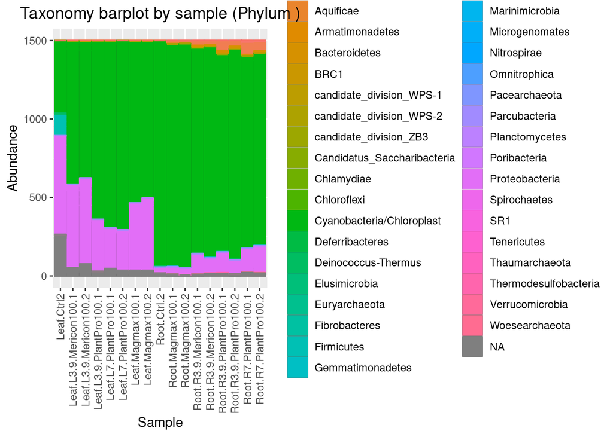

```r
plot_bar(physeq.prune.rarefy, x = "Sample", y = "Abundance", fill ="Phylum") +
  geom_bar(aes(color=Phylum, fill=Phylum), stat="identity", position="stack") +
  ggtitle("Taxonomy barplot by sample (Phylum )") +
  theme(plot.title = element_text(hjust = 0.5),axis.text.x = element_text(angle = 90, vjust = 0.5, hjust=1))
```

###Beta Diversity

```r
physeq.prune.rarefy.ps.ord <- ordinate(physeq.prune.rarefy, "PCoA", "unifrac")
```

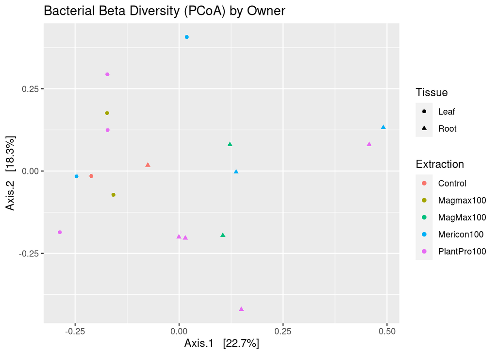

```r
plot_ordination(physeq.prune.rarefy, physeq.prune.rarefy.ps.ord, type = "samples", color = "Extraction",shape="Tissue")  + ggtitle("Bacterial Beta Diversity (PCoA) by Owner")
```

```r
taxcom_treatment = ggplot(data = psmelt(physeq.prune.rarefy), mapping = aes_string(x = "ExtractByTmt",
                                                                                   y = "Abundance",
                                                                                   fill = "Phylum" )) +
  geom_bar(stat="identity", position="fill") +
  ggtitle("Bacteria from pilot study")+
  theme(axis.text.x = element_text(angle = 90, hjust = 1)) +
  theme_bw() + theme(panel.grid.major = element_blank(), panel.grid.minor = element_blank(),
                     axis.text.x = element_text(angle = 90, vjust = 0.5, hjust=1)
                     ) +
  theme(plot.title = element_text(hjust = 0.5))
```

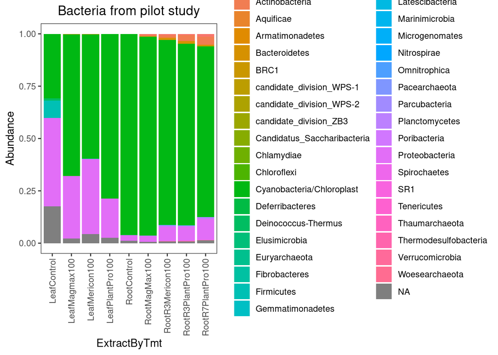

```r
print(taxcom_treatment)
```

Save plot

```r
pdf("../Figures/Plot_name.pdf", width = 6, height = 3.8)
print(taxcom_treatment)
dev.off()
```

###Plot Alpha Diversity (Species richness)

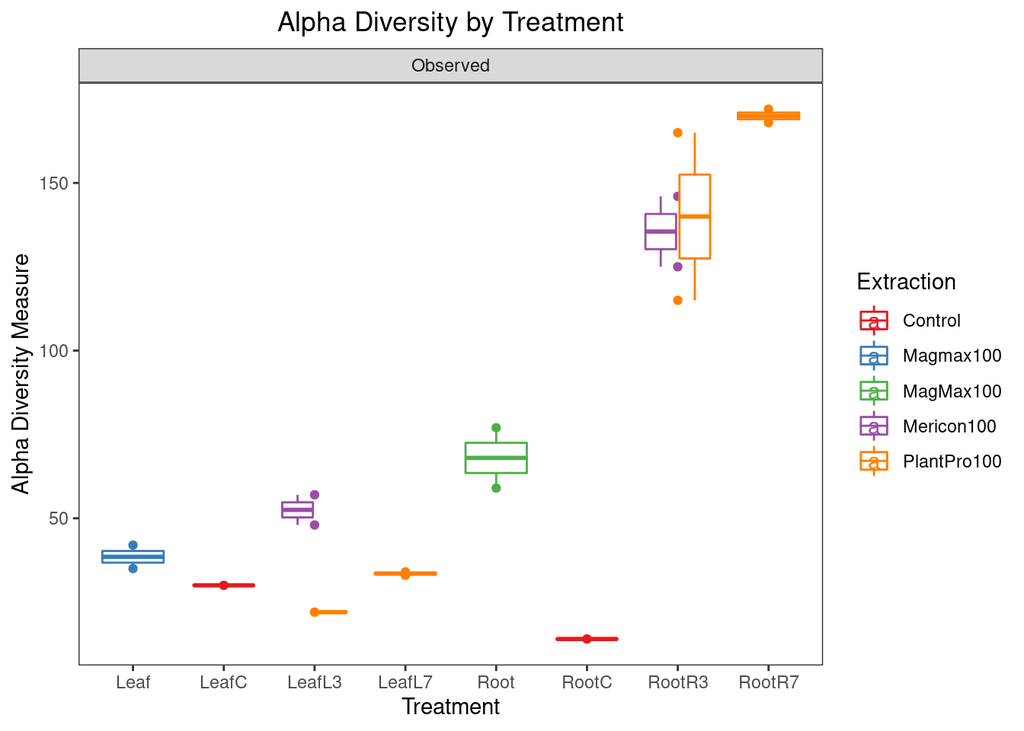

```r
physeq.prune.rarefy.plot.richness = plot_richness(physeq.prune.rarefy, x="Treatment", color=("Extraction"), measures=c("Observed")) + geom_boxplot(lwd=0.5) + ggtitle("Alpha Diversity by Treatment") + stat_compare_means(method = "t.test", label.x.npc = c("right")) + theme_bw() + scale_colour_brewer(palette="Set1") + theme(panel.grid.major = element_blank(), panel.grid.minor = element_blank())
physeq.prune.rarefy.plot.richness + theme(plot.title = element_text(hjust = 0.5))
```